# Model Selection and Validation

## Skills covered

- Review of linear regression
- Robust regression (M estimation)
- Cross-validation

## Birth weight

Birth weight is a commonly-used indicator of a newborn infant’s health status. Because this indicator is easily obtained, it is a critical component of population health reporting by the World Health Organization and governments around the globe. The distribution of birthweight has often been described as approximately normal, though the left tail in particular is inflated relative to that from a Gaussian distribution.

## Dealing with heavy-tailed distributions

Birth weight has heavy tails, or more observations in the tail than a typical normal distribution.

Fitting a linear regression model assumes the data follow an approximate normal distribution. Instead, we may want to consider a parametric family that has heavier tails and therefore better accommodates outliers in the data.

Let’s first start with linear regression.

## Read data into R

We will evaluate whether there is a relationship between the response, birth weight, and the predictors gestational age (measured in weeks) and sex.

- Check for NAs in data - appear as 9, 99, 9999 for our variables of interest (birth weight, gestational age, and sex)
- For now, remove the rows with missing values

```r
#Read in birth data
o_data <- read.csv("~/Documents/TEACHING/vitalstats/Yr1116Birth.csv",
  na.strings=c("9","99", "9999"))
#SEX=1 male, 2 female; male=1 male, 0 female
o_data$male=2-o_data$SEX #binary gender for interpretation

birth_data <- na.omit(o_data)
```

## Is birth weight normally distributed?

- Compare histogram of birth weight to a normal distribution parameterized with a mean and variance that is set based on birth weight variable, `BWTG`.
- Do the distributions align?

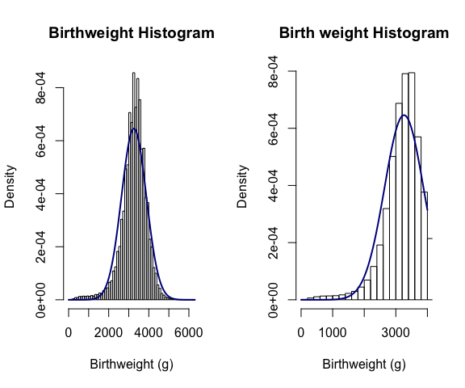

## Review of linear regression

Let $y_i$ denote the observed response, ‘BWTG’, for observation $i$, and $x_i$ the observed covariates, ‘GEST’ and ‘male’. Then we aim to fit the model:

$$y_i = \beta_0 + \beta_1 \text{GEST}_i + \beta_2 \text{male}_i + \epsilon_i$$

When we fit the line, we estimate the coefficients $\mathbf{\widehat{\beta}}= \{\widehat{\beta}_0, \widehat{\beta}_1, \widehat{\beta}_2\}$, where $\widehat{\beta} = (X^\prime X)^{-1} X^\prime Y$.

$$\widehat{y}_i = \widehat{\beta}_0 + \widehat{\beta}_1 \text{GEST}_i + \widehat{\beta}_2 \text{male}_i$$
We denote residuals, $e_i = y_i - \widehat{y}_i$ where $\widehat{y}_i$ is the estimated predicted value for observation $i$.

## Matrix Formulation of Regression

Wait, we did not talk about $\mathbf{\widehat{\beta}}= \{\widehat{\beta}_0, \widehat{\beta}_1, \widehat{\beta}_2\}$, where $\widehat{\beta} = (X^\prime X)^{-1} X^\prime Y$ in STA 210! This is something covered in 360 but not 210 – if you have not had STA 360, you should review the matrix formulation of regression [briefly](http://www.philender.com/courses/multivariate/notes/mr3.html) or [in greater detail](http://global.oup.com/booksites/content/0199268010/samplesec3).

## Model Assumptions

To make inference on the model parameters, $\beta$, we check four assumptions for the linear regression model:

1. The mean of the response, $E(y_i) = \beta_0 + \beta_1 \text{GEST}_i + \beta_2 \text{male}_i$ is **linear function** of the $x_i$ at each value of the predictors $x_i$.
2. The errors, $\epsilon_i$, are **independent**.
3. The errors, $\epsilon_i$, at each value of the predictor, $x_i$, are **normally distributed**.
4. The errors, $\epsilon_i$, at each value of the predictor, $x_i$, have **equal variances**.

Or in summary, we assume the errors, $\epsilon_i$, are independent, normally distributed with zero mean and constant variance:
$$\epsilon_i \overset{\text{iid}}{\sim} \text{Normal}(0, \sigma^2).$$

## Fit regression to data

Let’s fit a linear model using the function `lm`.

```r
model1 = lm(BWTG~GEST+male, data=birth_data)
summary(model1)
```

```
##
## Call:
## lm(formula = BWTG ~ GEST + male, data = birth_data)
##
## Residuals:
##     Min      1Q  Median      3Q     Max
## -9868.1  -293.4   -22.3   273.3  4819.0
##
## Coefficients:
##               Estimate Std. Error t value Pr(>|t|)
## (Intercept) -3969.9685     8.8988  -446.1   <2e-16 ***
## GEST          186.0392     0.2301   808.6   <2e-16 ***
## male          125.8233     1.0528   119.5   <2e-16 ***
## ---
## Signif. codes:  0 '***' 0.001 '**' 0.01 '*' 0.05 '.' 0.1 ' ' 1
##
## Residual standard error: 443.5 on 710367 degrees of freedom
## Multiple R-squared:  0.4838, Adjusted R-squared:  0.4838
## F-statistic: 3.33e+05 on 2 and 710367 DF,  p-value: < 2.2e-16
```

## Look at residuals

What do the residuals tell us about model fit?

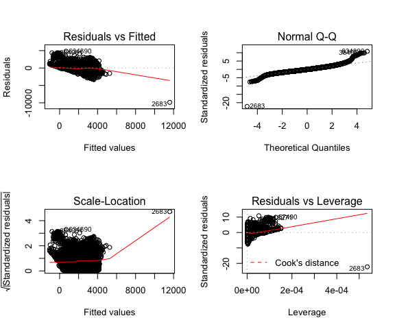

```r
par(mfrow=c(2,2))
plot(model1)
```

## Investigating the problem

Clearly we have a problem! Generally it is a good idea to start with exploratory data analysis rather than jumping right into modeling.

## Weight as a function of gestational age

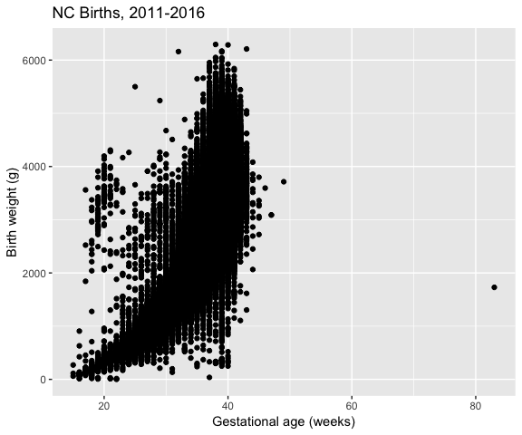

```r
ggplot(data = birth_data, mapping = aes(x = GEST, y = BWTG)) +
  geom_point() + xlab("Gestational age (weeks)") + ylab("Birth weight (g)") +
  ggtitle("NC Births, 2011-2016")
```

- Time for data cleaning! (Unless an Asian elephant snuck in….) - Why does the plot have a barred structure?

## Data Cleaning

Because it will complicate all our plotting, we’re going to set the gestational age of the baby that is presumably *NOT* an elephant given its weight (elephants have the longest gestation of all mammals) to NA. Because this is a file of live births, we’re going to do the same to gestational periods less than 20 weeks and birth weights below 500 g. Ideally, we would use a criterion to flag unreasonable combinations of birth weight and gestational age as well (but we will save that for you, if you’d like!).

```r
birth_data$GEST_C=birth_data$GEST
birth_data$BWTG_C=birth_data$BWTG
birth_data$GEST_C[birth_data$GEST_C>50]=NA
birth_data$GEST_C[birth_data$GEST_C<20]=NA
birth_data$BWTG_C[birth_data$BWTG_C<500]=NA
bdclean=na.omit(birth_data)
```

## Now refit the model

```r
model2 = lm(BWTG_C~GEST_C+male, data=bdclean)
summary(model2)
```

```
##
## Call:
## lm(formula = BWTG_C ~ GEST_C + male, data = bdclean)
##
## Residuals:
##     Min      1Q  Median      3Q     Max
## -2956.9  -294.7   -19.3   272.3  4879.6
##
## Coefficients:
##               Estimate Std. Error t value Pr(>|t|)
## (Intercept) -4140.5308     9.5509  -433.5   <2e-16 ***
## GEST_C        190.4367     0.2468   771.7   <2e-16 ***
## male          126.2132     1.0502   120.2   <2e-16 ***
## ---
## Signif. codes:  0 '***' 0.001 '**' 0.01 '*' 0.05 '.' 0.1 ' ' 1
##
## Residual standard error: 441.9 on 708696 degrees of freedom
## Multiple R-squared:  0.4616, Adjusted R-squared:  0.4616
## F-statistic: 3.038e+05 on 2 and 708696 DF,  p-value: < 2.2e-16
```

## Plotting in R

Aside: how well is this model fitting?

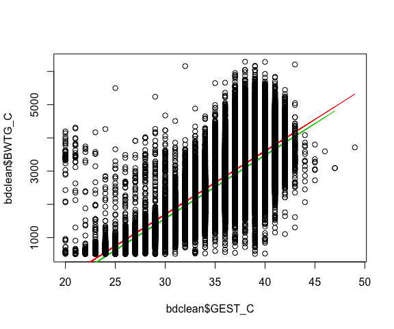

```r
 plot(bdclean$GEST_C, bdclean$BWTG_C, type="n")
lines(bdclean$GEST_C[bdclean$male==1],model2$fitted.values[bdclean$male==1],col=2)
lines(bdclean$GEST_C[bdclean$male==0],model2$fitted.values[bdclean$male==0],col=3)
points(bdclean$GEST_C,bdclean$BWTG_C)
```

## Guide to residual plots

- RxP plot (residuals versus fitted): you want to see a “happy cloud” of residuals with no obvious trends or patterns, centered around 0
- Q-Q plot (standardized residuals vs order stats from normal): want to see a straight line with slope 1
- Scale-Location plot (are residuals spread equally across range of predictors?): want equal spacing of points with horizontal smoother
- Residuals vs Leverage (are outliers influencing model fit?): look for points in top and bottom right side corners to see if outliers are also high leverage points that may affect fit of line

## Look at residuals

What do the residuals tell us about model fit?

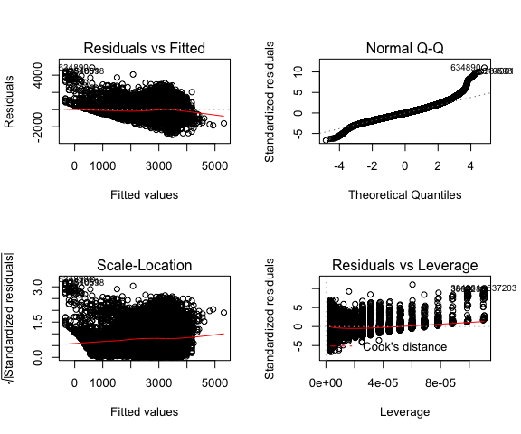

```r
par(mfrow=c(2,2))
plot(model2)
```

## Diagnosing the problem

Diagnostic plots of the model are essential for checking model fit.

Heavy-tailed data leads to large residuals and large deviations on the QQplot

A few tools for heavy-tailed data:

- Deletion of outliers - often done in practice, but throwing away data is generally a very bad idea
- Transformations (e.g. sqrt(BTWG)) - transforming outcome may fix the skewness but can make interpretting the model more difficult
- Robust regression - use a more flexible regression model to accommodate the data. While there are many methods for robust regression, they share a general strategy of giving lower weight to observations that have large influence on the regression model fit.

## What do we mean by robust?

- We define *robustness* as a lack of sensitivity to small deviations from the model assumptions
- We have particular interest in distributional robustness and the impact of outliers or non-normal distributions on our estimates
- Thus we will call a model robust if it has the following properties
  - Reasonably efficient
  - Small deviations from the model assumptions will not substantially impair model performance
  - Somewhat larger deviations will not completely invalidate model

## Robustness and linear regression

- Linear regression/ordinary least squares is not robust to outliers. In a small- to moderate-sized data set, one observation can have significant impact on estimates.
- Efficiency of least squares is hindered by heavy-tailed distributions
- Diagnostics can be used to detect outliers and influential points, but what do we do once we have identified them? Is it appropriate to remove them from the data if they represent valid observations? Often extreme observations (e.g., long-term survivors) are the most interesting in a data set.

## M-estimation

M-estimation simply solves estimating equations (similar to likelihood score equations) to obtain weighted estimators of the form $\widehat{\beta}^{(s)} = (X^\prime W^{(s-1)} X)^{-1} X^\prime W^{(s-1)} Y$, where $s$ is step $s$ in an interative algorithm, and $W$ is a diagonal weight matrix. An interative algorithm is needed because the weights generally depend on the residuals, and the residuals depend on the weights. In the special case in which $W$ is the identity matrix, we obtain maximum likelihood estimates (ordinary least squares); in fact, the “M” in M-estimation represents “maximum likelihood-type.”

## M-estimation

The weight matrix $W$ can be defined in a variety of ways; a popular choice is the use of Huber weights, in which observations with small residuals are given weights of 1, and observations with larger residuals are downweighted:

$\begin{aligned} w(\epsilon)= &1 ~~~~ \text{for} ~~ |\epsilon| \leq k \\ w(\epsilon)=&\frac{k}{|\epsilon|} ~ \text{for} ~~ |\epsilon|>k. \end{aligned}$

## M-estimation

The value for $k$ is called a *tuning constant*; smaller values produce more resistance to outliers at the cost of reduced efficiency if errors are in fact normally distributed. The value of $k$ is often tied to $\sigma$; for example, [Fox and Weisberg](http://users.stat.umn.edu/~sandy/courses/8053/handouts/robust.pdf) note that $k=1.345\sigma$ provides around 95% efficiency when errors are normal but still provides some protection against overly influential outliers. Because the estimate of $\sigma$ itself can be highly sensitive to outliers, often a robust estimate is used instead (e.g., $\frac{MAD}{0.6745}$), where $MAD=\text{median}(|y_i-\text{median}(y)|)$.

## M-estimation in R

We will explore frequentist robust regression via M-estimation using the function `rlm` in the `MASS` package. As a default, this package carries out estimation via M-estimation with Huber weights.

```r
library(MASS)
fit2 <- rlm(BWTG_C ~ GEST_C+male, data = bdclean)
summary(fit2)
```

```
##
## Call: rlm(formula = BWTG_C ~ GEST_C + male, data = bdclean)
## Residuals:
##       Min        1Q    Median        3Q       Max
## -2948.984  -282.311    -9.708   281.965  4930.915
##
## Coefficients:
##             Value      Std. Error t value
## (Intercept) -4264.0815     9.4020  -453.5303
## GEST_C        193.3266     0.2429   795.7874
## male          127.3770     1.0338   123.2107
##
## Residual standard error: 418 on 708696 degrees of freedom
```

How do these results compare to those of ordinary least squares?

## M-estimation in R

This robust regression technique works by reweighting the observations with large residuals. Let’s look at the observations with the largest and smallest weights. What do you notice?

```r
fit2_weights = data.frame(bwt = bdclean$BWTG_C, gest = bdclean$GEST_C,
  resid=fit2$resid, weight=fit2$w)
fit2_weights[order(fit2$w)[c(1:5, (length(fit2$w)-5):length(fit2$w))],]
```

```
##         bwt gest      resid    weight
## 634890 5500   25 4930.91544 0.1140188
## 384061 4139   20 4536.54865 0.1239308
## 510598 4281   21 4485.22201 0.1253490
## 637203 4196   20 4466.17163 0.1258839
## 380828 4026   20 4423.54865 0.1270967
## 721680 3115   38  -94.70792 1.0000000
## 721684 3000   39 -275.65754 1.0000000
## 721686 3510   39  234.34246 1.0000000
## 721688 3487   39  211.34246 1.0000000
## 721689 3715   39  311.96544 1.0000000
## 721690 3402   37  512.99575 1.0000000
```

## Class Exercises:

- Subset the data to Tyrrell County (CORES=89) and 2016 and evaluate whether linear and robust regression methods give similar results in the cleaned data. If not, why not?

```r
birth2016=subset(birth_data,birth_data$YOB=='2016')
#CORES code for Tyrrell Co is 89
tyrrell=subset(birth2016,birth2016$CORES=='89')
```

## Measuring model fit

One metric for measuring model fit is the mean squared error (MSE):
$$MSE=\frac{1}{n}\sum_{i=1}^n (y_i-\widehat{y}_i)^2.$$
This value will be small when our predictions $\widehat{y}_i$ are close to the true values $y_i$.

Data used in model development are often called *training data*, with the MSE called the *training MSE*. Ideally, our model would also work well for new data $(x_0, y_0)$: what does our model tell us about what might happen in the future?

## Training and test data

We generally expect the test MSE to be somewhat larger than the training MSE because our model has been developed to minimize the training MSE; overfitting refers to a situation in which a different model (generally a simpler one) fit to the training data would result in a smaller test MSE (indicating better out-of-sample prediction).

## Evaluating test MSE

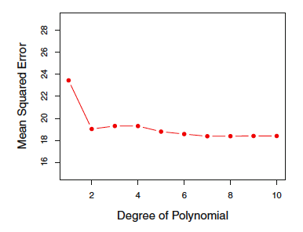

James et al (2013) consider test MSE for a variety of polynomial functions of a predictor variable $x$.

While it is difficult to choose among higher-order polynomials, it is clear that a linear term in $x$ is insufficient.

## Evaluating test MSE

In a small dataset, the random split of the data can have considerable impact on the results, as seen in this figure (also from James) that shows results from 10 different random 50:50 training:test data splits in a sample of just under 400 observations.

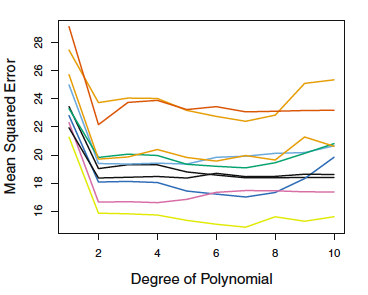

Some splits show more preference for a particular polynomial than others.

## Cross-validation

*Cross-validation* is related to the validation set method but addresses the issue of sensitivity of results to the particular random data split obtained.

*k-Fold cross-validation* involves splitting the data into $k$ mutually-exclusive groups, called *folds*, and then fitting a model on $k-1$ folds (combined) with the $k^{th}$ fold treated as a validation set. We repeat $k$ times (so each fold has a turn as the validation set). We obtain $k$ estimates of the test error and summarize using the average
$$\frac{1}{k}\sum_{i=1}^k MSE_i.$$

## Leave-one-out cross-validation

*Leave-one-out cross-validation*, in which $k=n$, is a special case (more computationally intensive except in special cases). Test error estimates using $k=5$ or $k=10$ have been shown to have good statistical properties, motivating these common choices.

## Leave-one-out cross-validation

In the case of least squares, we can get an estimate of the average MSE from leave-one-out cross-validation using a simple formula (sadly, this does not hold in other models) based on the fit of only one model! This is a great computational savings. The estimate is given by
$$\frac{1}{n}\sum_{i=1}^n \left(\frac{y_i-\widehat{y}_i}{1-h_i}\right)^2,$$
where $h_{i}$ is the $i$th diagonal element of the hat matrix $X(X'X)^{-1}X'$ and is often termed the *leverage*. High leverage points (close to 1) tend to have more of an impact on model fit.

## Class Exercises

- Subset the data to 2016 births in Duplin County (CORES=31).
- Evaluate the observations with largest residuals/weights and discuss possible reasons for the large residuals
- Divide the data into $k$ folds, where $k$ is the number of group members present, and assign each group member a different validation set (setting a seed may be helpful). See [helpful code](https://gist.github.com/duttashi/a51c71acb7388c535e30b57854598e77)

## Class Exercises:

- Each member should fit a regression model with birth weight as the outcome and predictors including biological sex, total pregnancies (dichotomized as 1 or >1), smoking status (dichotomized as any versus none), and gestational age (linear term in weeks) on their particular training set and compute the test MSE in their assigned validation set
- Combine results across team members to get the average test MSE
- Now compute average test MSE for a variety of polynomial functions in gestational age to determine a preferred model
- [R has a nice cross-validation function](https://www.rdocumentation.org/packages/DiceEval/versions/1.4/topics/crossValidation) for automating this in the future.